# TidyTuesday - Sports

Bryan Casanova

2022-03-30

## Presentación

El TidyTuesday de esta semana se relaciona a una base de datos de los gastos que realizan distintas universidades de Estados Unidos. Primero cargo y visualizo un poco los datos para saber qué datos tengo:

```r
library(tidyverse)
sports <- readr::read_csv('https://raw.githubusercontent.com/rfordatascience/tidytuesday/master/data/2022/2022-03-29/sports.csv') %>%
  as_tibble()
head(sports)
```

```
## # A tibble: 6 x 28
##    year unitid institution_name      city_txt state_cd zip_text classification_~
##   <dbl>  <dbl> <chr>                 <chr>    <chr>    <chr>               <dbl>
## 1  2015 100654 Alabama A & M Univer~ Normal   AL       35762                   2
## 2  2015 100654 Alabama A & M Univer~ Normal   AL       35762                   2
## 3  2015 100654 Alabama A & M Univer~ Normal   AL       35762                   2
## 4  2015 100654 Alabama A & M Univer~ Normal   AL       35762                   2
## 5  2015 100654 Alabama A & M Univer~ Normal   AL       35762                   2
## 6  2015 100654 Alabama A & M Univer~ Normal   AL       35762                   2
## # ... with 21 more variables: classification_name <chr>,
## #   classification_other <chr>, ef_male_count <dbl>, ef_female_count <dbl>,
## #   ef_total_count <dbl>, sector_cd <dbl>, sector_name <chr>, sportscode <dbl>,
## #   partic_men <dbl>, partic_women <dbl>, partic_coed_men <dbl>,
## #   partic_coed_women <dbl>, sum_partic_men <dbl>, sum_partic_women <dbl>,
## #   rev_men <dbl>, rev_women <dbl>, total_rev_menwomen <dbl>, exp_men <dbl>,
## #   exp_women <dbl>, total_exp_menwomen <dbl>, sports <chr>
```

Se puede encontrar una pequeña descripción de cada campo en el [github de TidyTuesday](https://github.com/rfordatascience/tidytuesday/blob/master/data/2022/2022-03-29/readme.md)

## Primeras visualizaciones

```r
sports %>%
  group_by(Estado = state_cd) %>%
  summarize(Gasto_promedio = mean(total_exp_menwomen, na.rm = T)) %>%
  arrange(desc(Gasto_promedio))
```

```
## # A tibble: 54 x 2
##    Estado Gasto_promedio
##    <chr>           <dbl>
##  1 UT           1877039.
##  2 NV           1674674.
##  3 LA           1299138.
##  4 AL           1254168.
##  5 FL           1228019.
##  6 TX           1187310.
##  7 SC           1153075.
##  8 AZ           1130066.
##  9 HI           1105532.
## 10 OK           1065351.
## # ... with 44 more rows
```

Ok, se ven números muy grandes pero la verdad no manejo los códigos de los estados, por lo que me gustaría ver un mapa y por ejemplo saber si hay un comportamiento espacial en este gasto promedio.

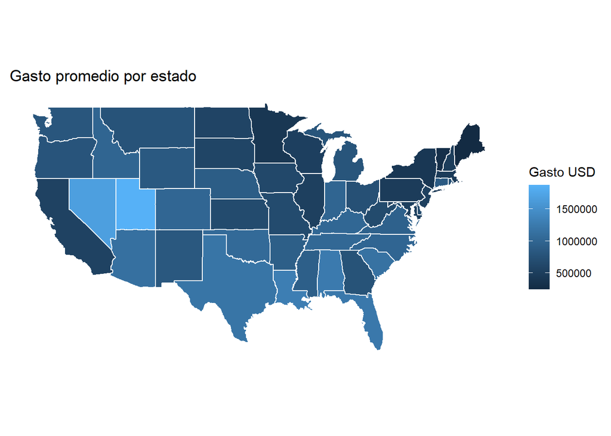

```r
library(usmap)

us <- usmap::us_map()
# us2 <-  left_join(us, sports %>%
#               group_by(Estado = state_cd) %>%
#               summarize(Gasto_promedio = mean(total_exp_menwomen, na.rm = T)),
#               by = c("abbr" ="Estado"))

gastoprom_est <- sports %>%
              group_by(Estado = state_cd) %>%
              summarize(Gasto_promedio = mean(total_exp_menwomen, na.rm = T)) %>%
                  left_join(us %>% select(abbr,full) %>% distinct(),
                      by = c("Estado" ="abbr"))

state <- map_data("state") %>% left_join(gastoprom_est %>%  select(-Estado) %>% mutate(full=tolower(full)), by = c("region" ="full"))
ggplot(data=state, aes(x=long, y=lat, fill=Gasto_promedio, group=group)) +
  geom_polygon(color = "white") +
  theme(axis.title.x=element_blank(), axis.text.x=element_blank(), axis.ticks.x=element_blank(),
        axis.title.y=element_blank(), axis.text.y=element_blank(), axis.ticks.y=element_blank(),
        legend.position = "right") +
  labs(title = 'Gasto promedio por estado', fill = "Gasto USD") +
  coord_fixed(1.3) +
  theme(panel.background=element_blank())
```

## Existen diferencias entre la inversión entre deportistas hombres y mujeres?

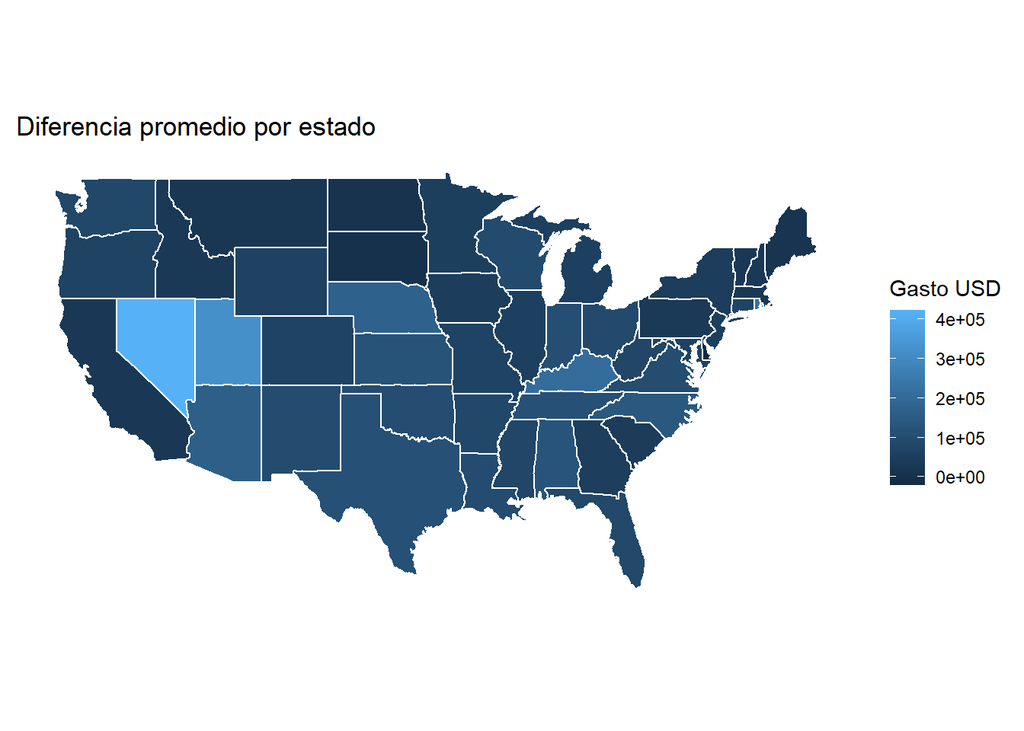

```r
difprom_sexo <- sports %>%
              select(state_cd, exp_men,exp_women) %>%
              na.omit() %>%
              mutate(Dif = exp_men - exp_women) %>%
              group_by(Estado = state_cd) %>%
              summarize(Dif_promedio = mean(Dif, na.rm = T)) %>%
                  left_join(us %>% select(abbr,full) %>% distinct(),
                      by = c("Estado" ="abbr"))


state <- map_data("state") %>% left_join(difprom_sexo %>%  select(-Estado) %>% mutate(full=tolower(full)), by = c("region" ="full"))
ggplot(data=state, aes(x=long, y=lat, fill=Dif_promedio, group=group)) +
  geom_polygon(color = "white") +
  theme(axis.title.x=element_blank(), axis.text.x=element_blank(), axis.ticks.x=element_blank(),
        axis.title.y=element_blank(), axis.text.y=element_blank(), axis.ticks.y=element_blank(),
        legend.position = "right") +
  labs(title = 'Diferencia promedio por estado', fill = "Gasto USD") +
  coord_fixed(1.3) +
  theme(panel.background=element_blank())
```

## Pendiente

Realizar evaluación de correlación Pasar a gráficos dinámicos Evaluar algo a nivel de universidad Evaluar los ingresos Evaluar gasto estado/universidad en deportes según número de alumnos, sacar un worst 10